# Homework 3

## **Due Date:** 2022-10-30 at 8:30 AM PT

**Name:** Sabahat

## Preparation

1. Create a ‘code’ folder in the root directory of your repository.
2. Inside the ‘code’ folder, create a file ‘01_clean_data.<your_extension_here>’. Your extension should be the one you use for your programming language of choice (e.g., ‘.R’ for R, ‘.py’ for Python, ‘.jl’ for Julia).
3. Copy any code from HW_02 you need to subset and merge the NRI and SVI datasets into the ‘01_clean_data’ file.
4. Add a ‘processed’ directory to the ‘data’ folder.
5. Add a line at the end of the file that saves the merged dataset to ‘data/processed’ directory.
6. Run the ‘01_clean_data’ file to ensure that the merged dataset runs and creates the proper file.
7. Add and commit the ‘01_clean_data’ file to the repository. Answer: Did all steps

#`Importing all the extensions.`

```python
import pandas as pd
import os
from sklearn.decomposition import PCA
from sklearn.preprocessing import StandardScaler
import matplotlib.pyplot as plt
import numpy as np
from joblib import Parallel, delayed
from sklearn.model_selection import KFold
```

## Homework - Principal Component Analysis

## a. Subset the merged dataset to only include the variables above and look at the pattern of missing data. Are missing observations scattered throughout the data or are entire rows or columns missing?

#a.`Subset the Merged Dataset.`

```python
import pandas as pd
svi_variables = [
    'EP_POV150', 'EP_UNEMP', 'EP_HBURD', 'EP_NOHSDP', 'EP_UNINSUR',
    'EP_AGE65', 'EP_AGE17', 'EP_DISABL', 'EP_SNGPNT', 'EP_LIMENG',
    'EP_MINRTY', 'EP_MUNIT', 'EP_MOBILE', 'EP_CROWD', 'EP_NOVEH',
    'EP_GROUPQ', 'EP_NOINT'
]
# Loading the data with defined columns
# Load the data with defined columns
file_path = 'C:/Users/sabahat/Desktop/ML-Folder/Sabahat-PRGS-Intro-to-ML-2024/homework/code/data/processed/merged_dataset.csv'
svi_data = pd.read_csv(file_path, usecols=svi_variables)

# Check the first few rows to confirm
print(svi_data.head())
# Checking missing data pattern
missing_data_summary = svi_data.isnull().sum()
print(missing_data_summary)
```

```
   EP_POV150  EP_UNEMP  EP_HBURD  EP_NOHSDP  EP_UNINSUR  EP_AGE65  EP_AGE17  \
0       20.2       2.8      19.7        9.6         7.4      15.6      23.4
1       18.3       3.4      23.2        8.4         9.3      21.2      21.2
2       37.7       5.8      25.1       23.5        10.7      19.8      20.7
3       29.0       8.7      23.2       21.1         8.4      16.8      21.2
4       22.9       6.0      19.4       18.2        10.2      18.3      23.0

   EP_DISABL  EP_SNGPNT  EP_LIMENG  EP_MINRTY  EP_MUNIT  EP_MOBILE  EP_CROWD  \
0       16.4        5.6        0.4       27.4       3.9       15.6       1.4
1       13.9        4.2        0.8       17.7      16.6       10.2       1.9
2       18.1       11.3        2.0       55.4       1.4       29.2       3.8
3       19.6        7.2        0.3       25.8       2.7       30.6       1.3
4       17.0        5.3        2.2       14.3       0.9       23.9       2.3

   EP_NOVEH  EP_GROUPQ  EP_NOINT
0       4.0        0.9      10.9
1       2.3        1.5      10.9
2      11.7       12.0      31.8
3       7.5        6.4      20.2
4       4.8        1.0      16.9
EP_POV150     96
EP_UNEMP      96
EP_HBURD      96
EP_NOHSDP     96
EP_UNINSUR    96
EP_AGE65      96
EP_AGE17      96
EP_DISABL     96
EP_SNGPNT     96
EP_LIMENG     96
EP_MINRTY     96
EP_MUNIT      96
EP_MOBILE     96
EP_CROWD      96
EP_NOVEH      96
EP_GROUPQ     96
EP_NOINT      96
dtype: int64
```

##b. PCA cannot handle missing values by default.There are several options for handling missing data generally, including imputation, removing rows with missing data, or removing columns with missing data. Deal with the missing data in a way that makes sense for the pattern of missing data and the goals of the analysis. Explain why you made this decision. _Note: How you handle this is specific to the missing data pattern and the goals of the analysis. For example, when entire rows or columns are missing, imputation may not be appropriate and dropping those rows or columns is usually the best option Conversely, if you have a general missingness pattern where missing observations are scattered throughout the data, imputation is likely the best option

#`Checking for rows where all values are missing and treatment afterwards.`

```python
fully_missing_rows = svi_data.isnull().all(axis=1)

# Count the number of fully missing rows
num_fully_missing_rows = fully_missing_rows.sum()
print(f"Number of fully missing rows: {num_fully_missing_rows}")

# Display fully missing rows
missing_rows_data = svi_data[fully_missing_rows]
print(missing_rows_data)

# Remove fully missing rows
cleaned_data = svi_data.dropna(how='all')

# Verify the removal
print(f"Data shape after removal: {cleaned_data.shape}")

# Check if there are any missing values in the dataset
has_missing = cleaned_data.isnull().any().any()
print(f"Are there any missing values? {has_missing}")

# Count missing values in each column
missing_summary = cleaned_data.isnull().sum()
print("Missing values per column:\n", missing_summary)
# After cleaning, ensuring the cleaned data is assigned to the correct variable
cleaned_data = svi_data.dropna(how='all')  # Example cleaning step
```

```
Number of fully missing rows: 96
      EP_POV150  EP_UNEMP  EP_HBURD  EP_NOHSDP  EP_UNINSUR  EP_AGE65  \
309         NaN       NaN       NaN        NaN         NaN       NaN
310         NaN       NaN       NaN        NaN         NaN       NaN
311         NaN       NaN       NaN        NaN         NaN       NaN
312         NaN       NaN       NaN        NaN         NaN       NaN
313         NaN       NaN       NaN        NaN         NaN       NaN
...         ...       ...       ...        ...         ...       ...
3235        NaN       NaN       NaN        NaN         NaN       NaN
3236        NaN       NaN       NaN        NaN         NaN       NaN
3237        NaN       NaN       NaN        NaN         NaN       NaN
3238        NaN       NaN       NaN        NaN         NaN       NaN
3239        NaN       NaN       NaN        NaN         NaN       NaN

      EP_AGE17  EP_DISABL  EP_SNGPNT  EP_LIMENG  EP_MINRTY  EP_MUNIT  \
309        NaN        NaN        NaN        NaN        NaN       NaN
310        NaN        NaN        NaN        NaN        NaN       NaN
311        NaN        NaN        NaN        NaN        NaN       NaN
312        NaN        NaN        NaN        NaN        NaN       NaN
313        NaN        NaN        NaN        NaN        NaN       NaN
...        ...        ...        ...        ...        ...       ...
3235       NaN        NaN        NaN        NaN        NaN       NaN
3236       NaN        NaN        NaN        NaN        NaN       NaN
3237       NaN        NaN        NaN        NaN        NaN       NaN
3238       NaN        NaN        NaN        NaN        NaN       NaN
3239       NaN        NaN        NaN        NaN        NaN       NaN

      EP_MOBILE  EP_CROWD  EP_NOVEH  EP_GROUPQ  EP_NOINT
309         NaN       NaN       NaN        NaN       NaN
310         NaN       NaN       NaN        NaN       NaN
311         NaN       NaN       NaN        NaN       NaN
312         NaN       NaN       NaN        NaN       NaN
313         NaN       NaN       NaN        NaN       NaN
...         ...       ...       ...        ...       ...
3235        NaN       NaN       NaN        NaN       NaN
3236        NaN       NaN       NaN        NaN       NaN
3237        NaN       NaN       NaN        NaN       NaN
3238        NaN       NaN       NaN        NaN       NaN
3239        NaN       NaN       NaN        NaN       NaN

[96 rows x 17 columns]
Data shape after removal: (3144, 17)
Are there any missing values? False
Missing values per column:
 EP_POV150     0
EP_UNEMP      0
EP_HBURD      0
EP_NOHSDP     0
EP_UNINSUR    0
EP_AGE65      0
EP_AGE17      0
EP_DISABL     0
EP_SNGPNT     0
EP_LIMENG     0
EP_MINRTY     0
EP_MUNIT      0
EP_MOBILE     0
EP_CROWD      0
EP_NOVEH      0
EP_GROUPQ     0
EP_NOINT      0
dtype: int64
```

#`Answer:There were 96 rows showing no data. All these 96 rows have been removed. The data is showing zero missing values accross all the columns, so there is no need to apply imputation techniques.`

##a. After dealing with the missing data, perform PCA on the SVI variables.

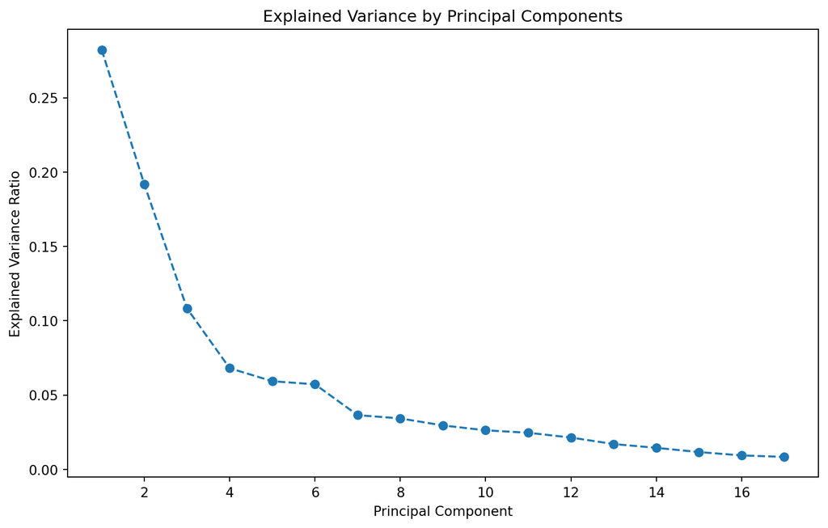

```
Explained variance ratio for each component:
PC1: 0.2823
PC2: 0.1917
PC3: 0.1083
PC4: 0.0680
PC5: 0.0593
PC6: 0.0572
PC7: 0.0364
PC8: 0.0343
PC9: 0.0295
PC10: 0.0263
PC11: 0.0246
PC12: 0.0214
PC13: 0.0170
PC14: 0.0145
PC15: 0.0116
PC16: 0.0094
PC17: 0.0084
```

```python
# Standardizing the data
scaler = StandardScaler()
svi_data_standardized = scaler.fit_transform(cleaned_data)
# Performing PCA
pca = PCA()
pca.fit(svi_data_standardized)

# Getting the explained variance
explained_variance = pca.explained_variance_ratio_

# Plotting the explained variance
plt.figure(figsize=(10, 6))
plt.plot(range(1, len(explained_variance) + 1), explained_variance, marker='o', linestyle='--')
plt.title('Explained Variance by Principal Components')
plt.xlabel('Principal Component')
plt.ylabel('Explained Variance Ratio')
plt.show()

# Print explained variance for each component
print("Explained variance ratio for each component:")
for i, var_ratio in enumerate(explained_variance, start=1):
    print(f"PC{i}: {var_ratio:.4f}")

# Extract loadings
loadings = pca.components_.T
```

##1. Plot the eigenvectors or loadings associated of the first three principal components.Make sure that the axis labels correspond to the variable names and not the indices of the variables.

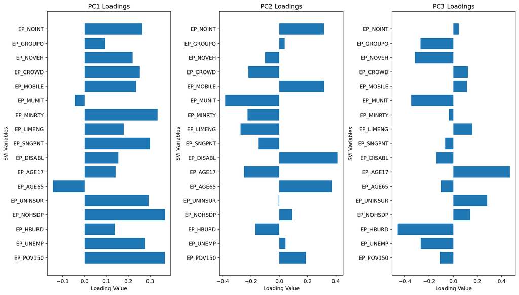

```python
# Plot loadings for the first three principal components
plt.figure(figsize=(14, 8))
for i in range(3):
    plt.subplot(1, 3, i + 1)
    plt.barh(svi_variables, loadings[:, i])
    plt.title(f'PC{i+1} Loadings')
    plt.xlabel('Loading Value')
    plt.ylabel('SVI Variables')

plt.tight_layout()
plt.show()
```

## How would you interpret the first three prinicpal components?_Note: you can find the documentation for the SVI variables [here].

#`Answer:The PC1 highlights the economic and social vulnerability. It suggests that all the varaibles move in the same direction and contributing positively to economic and social vulnerability. The only two varibales i.e., the group of people aged 65 and people living in hosing in large structures contributed negatively which might indiccate higher economic stability. The PC2 depicts vulnerabilities associated with age and connectivity. It suggest that five variables including Age65+, prevalence of disability, mobile homes, and lack of internet positively contribute to economic and social stress. The variables such as housing in large Units and limited english proficiency seem to have negative contribution and suggest more stable environment. The PC3 highlights educational and linguistic challenges. It shows that no high school diploma, no insurance, youth, limited english proficiency are positively contributed to educational and linguistic challenges. The variables such as lower unemployment, reduced housing cost burden, large housing structures all improve the educational and liguistic challenges.`

##1. There are several different ways to determine the number of principal components to retain.One common method is to retain principal components that explain a certain percentage of the variance in the data.a. How many principal components are needed to explain 80% of the variance in the data? a. How many principal components are needed to explain 90% of the variance in the data?

```python
# Calculate cumulative explained variance
cumulative_variance = np.cumsum(pca.explained_variance_ratio_)

# Determine number of components for 80% and 90% variance
num_components_80 = np.argmax(cumulative_variance >= 0.80) + 1
num_components_90 = np.argmax(cumulative_variance >= 0.90) + 1

print(f"Number of components to explain 80% of variance: {num_components_80}")
print(f"Number of components to explain 90% of variance: {num_components_90}")
```

```
Number of components to explain 80% of variance: 7
Number of components to explain 90% of variance: 11
```

#`Answer:Number of components to explain 80% of variance: 7. Number of components to explain 90% of variance: 11.`

##1. An alternative approach is to plot the eigenvalues of the principal components and retain the components that are above the “elbow” in the plot. In other words the eigenvalues that are substantially larger than the rest. a. Create a [scree plot](https://en.wikipedia.org/wiki/Scree_plot) of the eigenvalues of the principal components. # `Plot the scree plot`

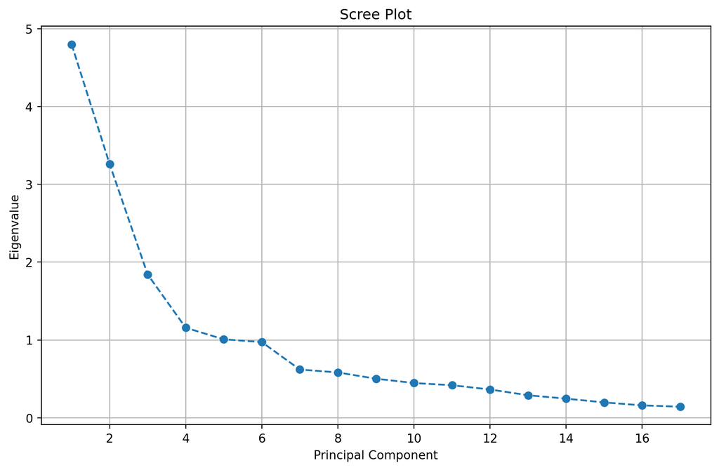

```python
eigenvalues = pca.explained_variance_
plt.figure(figsize=(10, 6))
plt.plot(range(1, len(eigenvalues) + 1), eigenvalues, marker='o', linestyle='--')
plt.title('Scree Plot')
plt.xlabel('Principal Component')
plt.ylabel('Eigenvalue')
plt.grid(True)
plt.show()
```

##a. How many principal components should be retained based on the scree plot?

#`Answer:Based on this principal component graph, it seems that from point PC4 to PC6 the slope of the curve changed significantly and this may reffered to as the elbow. After that eigen values started to tapered off slowly indicating diminishing returns in terms of variance. So we can retain 6 principal componenets.`

##1. Cross-validation is another method to determine the number of principal components to retain.This process requires some linear algebra that is beyond the scope of this course.As such, I have written example [code](https://github.com/gabehassler/PRGS-Intro-to-ML-2024/blob/main/examples/pca_cross_validation.jl) in Julia that demonstrates how to perform cross-validation. This procedure is a simplified versionof an approach explained in this [blog post](https://alexhwilliams.info/itsneuronalblog/2018/02/26/crossval/). For the purposes of this assignment, the `pca_cv_error` function is a black box that returns the cross-validation error for a given number of principal components. *Note: If you use a different programming language, you can use ChatGPT to translate the code to your language of choice.* a. Compute the cross-validation error for 1 to 17 principal components. If this process is parallelizable, parallelize the code. If setting a random number seed would make this work more reproducible, set a random number seed.

```
Optimal number of principal components: 1
```

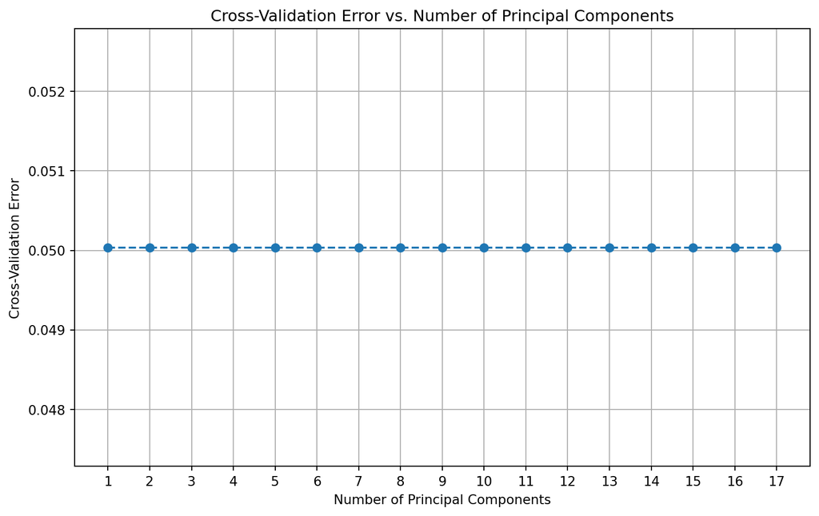

```python
# Function to approximate the data matrix X using the first k principal components
def pca_approx(X, k):
    pca = PCA(n_components=k)
    X_transformed = pca.fit_transform(X)
    X_approx = pca.inverse_transform(X_transformed)
    return X_approx
# Function to compute the cross-validated error of approximating X using the first k principal components
def pca_cv_error(X, k, n_folds=20, random_seed=42):
    kf = KFold(n_splits=n_folds, shuffle=True, random_state=random_seed)
    errors = []

    for train_index, test_index in kf.split(X):
        X_train, X_test = X[train_index], X[test_index]

        # Compute column means
        column_means = np.mean(X_train, axis=0)

        # Replace test set with column means
        X_cv = X_test.copy()
        X_cv[:] = column_means

        # Approximate X_cv using the first k principal components
        X_hat = pca_approx(X_cv, k)

        # Compute the error of the approximation for the test set
        error = np.sum((X_hat - X_test) ** 2)
        errors.append(error)

    # Return the average error
    return np.mean(errors) / X.size
    # Set random seed for reproducibility
random_seed = 42

# Compute the cross-validated error for k = 1 to 17
errors = [pca_cv_error(svi_data_standardized, k, random_seed=random_seed) for k in range(1, 18)]

# Determine the optimal number of principal components
optimal_k = np.argmin(errors) + 1
print(f"Optimal number of principal components: {optimal_k}")
#Plotting Cross-Validation Error
plt.figure(figsize=(10, 6))
plt.plot(range(1, 18), errors, marker='o', linestyle='--')
plt.title('Cross-Validation Error vs. Number of Principal Components')
plt.xlabel('Number of Principal Components')
plt.ylabel('Cross-Validation Error')
plt.xticks(range(1, 18))
plt.grid(True)
plt.show()
```